# COMP 112 FINAL PROJECT

Tam, Ting and Chris

[link to git collab](https://github.com/thuang111/Ting_Tam_Chris_final_project)

```r
library(tidyverse)     # for graphing and data cleaning
library(lubridate)     # for date manipulation
library(ggthemes)# for even more plotting themes
library(janitor)
library(geomtextpath)
library(tidyr)
library(maps)          # for map data
library(ggmap)         # for mapping points on maps
library(patchwork)
library(tidytext)
theme_set(theme_minimal()) # My favorite ggplot() theme :)
```

```r
data("world_bank_pop") #pop data only available from 2000 to 2017. So we might want to filter out some years from the original data set - Tam
world_map <- map_data("world") %>%  #coordinates of countries
  rename(country = region) %>%
  select(-subregion)
```

```r
world_pop_new <- world_bank_pop %>%
  pivot_longer(cols = starts_with("20") ,
              names_to = "year",
              values_to = "value") %>%
  pivot_wider(names_from = indicator,
              values_from =  value) %>%
  rename(country_code = country, population_growth = SP.POP.GROW ,  total_population = SP.POP.TOTL, urban_population_growth = SP.URB.GROW , total_urban_population = SP.URB.TOTL)
```

```r
cancer_og <- read_csv("total-cancer-deaths-by-type.csv")
cancer <- cancer_og %>%
  pivot_longer(cols = starts_with("Death"),
               names_to = "Type_of_cancer",
               values_to = "Death_count") %>%
  mutate(Cancer_type = str_sub(Type_of_cancer, 10, -37)) %>%
  select(-Type_of_cancer)
```

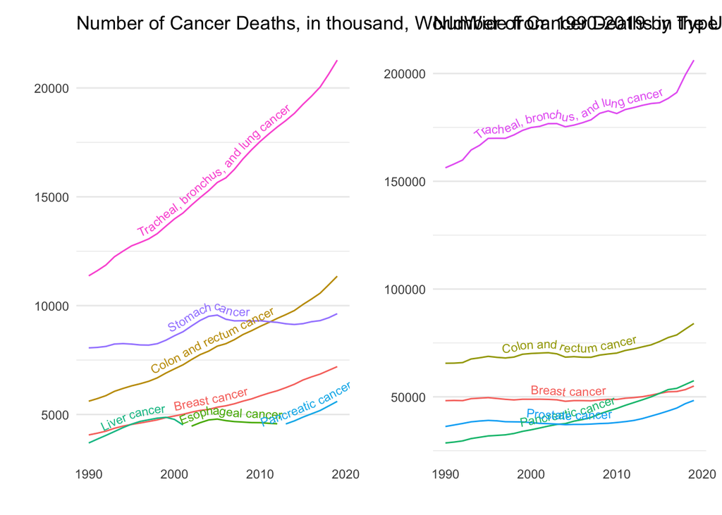

```r
USA_cancer <- cancer %>%
  filter(Code == "USA") %>%
  group_by(Year) %>%
  slice_max(Death_count, n=5) %>% #Top 5 cancer types each year in the USA, instead of cancer types with death count > 25000 because the graph looked too busy for me. However, we could change back if necessary - Tam
  ggplot(aes(x = Year, y = Death_count, color = Cancer_type, label = Cancer_type)) +
  geom_textline(aes(label = Cancer_type), size = 3, vjust = -0.5)+
  labs(x = "",
       y = "",
       title = "Number of Cancer Deaths in the US from 1990-2019 by Type of Cancer",
       color = "Cancer") +
  theme(legend.position = "none",
        panel.grid.minor.x = element_blank(),
        panel.grid.major.x = element_blank())

World_cancer <- cancer %>%
  group_by(Year, Cancer_type) %>%
  summarize(total_count = sum(Death_count)/1000) %>%
  slice_max(total_count, n=5) %>%
  ggplot(aes(x = Year, y = total_count, color = Cancer_type, label = Cancer_type)) +
  geom_textline(aes(label = Cancer_type), size = 3, vjust = -0.5)+
  labs(x = "",
       y = "",
       title = "Number of Cancer Deaths, in thousand, WorldWide from 1990-2019 by Type of Cancer",
       color = "Cancer") +
  theme(legend.position = "none",
        panel.grid.minor.x = element_blank(),
        panel.grid.major.x = element_blank())
World_cancer +USA_cancer
```

```r
#You know how to create a legend consisting of only shared cancer types for world and Usa? We can also adjust width and height of fig to show the graphs better - Tam
```

Discussion: Compare Trachael, bronchus, and lung cancer causes most death by far for both world and USA. Furthermore, both world and the USA have colon and rectum cancer, pancreatic cancer and breast cancer in their top 5. Contrast For USA, top 5 cancers stayed the same over time, only the ranks changed, however, for the world, we could also see the fifth position change to a different cancer type every 10 years or so. Moreover, while stomach cancer is a huge problem for the world, this isn’t the case for the US.

Most cancer deaths rise less extremely than lung cancer **where did you observe this? - Tam**

Q1: We are also interested to see which countries led the world in terms of death per 1,000 people. Which countries were in the top 5 (?) in the year 2000,2008 and 2017? Q2: Rising death counts may correlate with rising world population (i.e total growth, urban growth)? **I have downloaded the dataset that does just this, check out world_pop_new - Tam** Q3: In those countries, what are the cancer types that have caused the most deaths per 1000 people?

```r
#Join the cancer and the population datasets
cancer_pop <-
  cancer %>%
  rename(country_code = Code, year = Year, country = Entity) %>%
  group_by(country_code, year, country) %>%
  summarize(death = sum(Death_count)) %>%
  ungroup() %>%
  filter(!year %in% c(1990,1991,1992,1993,1994,1995,1996,1997,1998,1999,2018,2019)) %>%
  left_join(world_pop_new %>%
              mutate(year = as.numeric(year)),
            by = c("country_code","year")) %>%
  mutate(death_per_urban = death/total_urban_population*1000 , death_per_total = death/ total_population*1000)
cancer_pop
```

| country_code | year | country | death | total_urban_population | urban_population_growth | total_population | population_growth | death_per_urban | death_per_total |
| --- | --- | --- | --- | --- | --- | --- | --- | --- | --- |
| AFG | 2000 | Afghanistan | 12429 | 4436299 | 3.9122284596 | 20093756 | 3.494658738 | 2.8016597 | 0.6185504 |
| AFG | 2001 | Afghanistan | 12736 | 4648055 | 4.6628382244 | 20966463 | 4.251504112 | 2.7400708 | 0.6074463 |
| AFG | 2002 | Afghanistan | 12846 | 4892951 | 5.1346745425 | 21979923 | 4.720528462 | 2.6254095 | 0.5844424 |
| AFG | 2003 | Afghanistan | 13262 | 5155686 | 5.2304585349 | 23064851 | 4.818041120 | 2.5723056 | 0.5749875 |
| AFG | 2004 | Afghanistan | 13604 | 5426770 | 5.1243930194 | 24118979 | 4.468918396 | 2.5068319 | 0.5640371 |
| AFG | 2005 | Afghanistan | 13774 | 5691823 | 4.7686469975 | 25070798 | 3.870470159 | 2.4199628 | 0.5494041 |
| AFG | 2006 | Afghanistan | 13925 | 5931413 | 4.1231881089 | 25893450 | 3.228629843 | 2.3476699 | 0.5377808 |
| AFG | 2007 | Afghanistan | 14100 | 6151939 | 3.6504852122 | 26616792 | 2.755225384 | 2.2919603 | 0.5297408 |
| AFG | 2008 | Afghanistan | 14308 | 6364968 | 3.4041887823 | 27294031 | 2.512573879 | 2.2479296 | 0.5242172 |
| AFG | 2009 | Afghanistan | 14516 | 6588859 | 3.4570987898 | 28004331 | 2.569114319 | 2.2031129 | 0.5183484 |

[output cut: 4796 more lines]

```r
top_5_cancer_pop <-cancer_pop %>%
  select(country, country_code, year, death, total_urban_population,death_per_urban, total_population, death_per_total)

top_5_cancer_pop
```

| country | country_code | year | death | total_urban_population | death_per_urban | total_population | death_per_total |
| --- | --- | --- | --- | --- | --- | --- | --- |
| Afghanistan | AFG | 2000 | 12429 | 4436299 | 2.8016597 | 20093756 | 0.6185504 |
| Afghanistan | AFG | 2001 | 12736 | 4648055 | 2.7400708 | 20966463 | 0.6074463 |
| Afghanistan | AFG | 2002 | 12846 | 4892951 | 2.6254095 | 21979923 | 0.5844424 |
| Afghanistan | AFG | 2003 | 13262 | 5155686 | 2.5723056 | 23064851 | 0.5749875 |
| Afghanistan | AFG | 2004 | 13604 | 5426770 | 2.5068319 | 24118979 | 0.5640371 |
| Afghanistan | AFG | 2005 | 13774 | 5691823 | 2.4199628 | 25070798 | 0.5494041 |
| Afghanistan | AFG | 2006 | 13925 | 5931413 | 2.3476699 | 25893450 | 0.5377808 |
| Afghanistan | AFG | 2007 | 14100 | 6151939 | 2.2919603 | 26616792 | 0.5297408 |
| Afghanistan | AFG | 2008 | 14308 | 6364968 | 2.2479296 | 27294031 | 0.5242172 |
| Afghanistan | AFG | 2009 | 14516 | 6588859 | 2.2031129 | 28004331 | 0.5183484 |

[output cut: 4796 more lines]

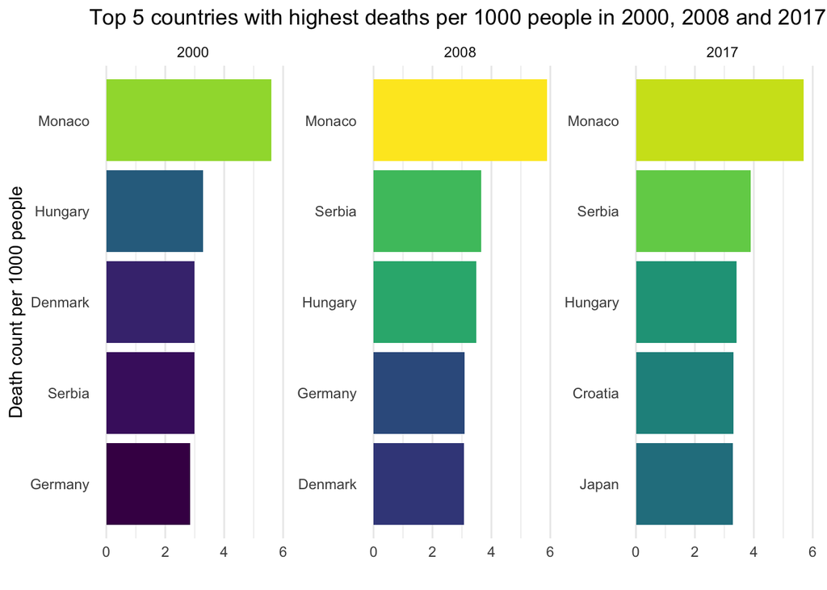

```r
fig2a <- top_5_cancer_pop %>%
  filter(year %in% c(2000,2008,2017)) %>%
  group_by(year) %>%
  slice_max(death_per_total, n = 5) %>%
  ungroup() %>%
  mutate(country = reorder_within(country, death_per_total, as.character(year), fun = sum, sep = "___")) %>%
  ggplot(aes(y = country, x = death_per_total, fill = country)) +
  geom_col()+
  scale_fill_viridis_d()+ #scale_fill to show that death rates actually increased over time. We are seeing more and more light colors than dark ones.
  facet_wrap(~year, scales = "free_y")+
  scale_y_reordered()+
  labs(title = "Top 5 countries with highest deaths per 1000 people in 2000, 2008 and 2017",
       x = "",
       y = "Death count per 1000 people")+
    theme(legend.position = "none",
          plot.title = element_text(hjust = 0.5),
          panel.grid.major.y = element_blank(),
          panel.grid.minor.y = element_blank())

fig2a
```

Why? -> Maybe do some research for possible explanations? The link below may help, idk.

[Cancer death rates by country](https://www.worldlifeexpectancy.com/cause-of-death/all-cancers/by-country/)

```r
fig2b <- cancer %>%
  rename(country_code = Code, year = Year) %>%
  filter(Entity %in% c("Monaco","Hungary","Denmark", "Serbia", "Gernamy", "Croatia", "Japan"), year %in% c(2000,2008,2017)) %>%
  left_join(world_pop_new %>%
              filter(year %in% c(2000,2008,2017)) %>%
              mutate(year = as.numeric(year)),
            by = c("country_code","year")) %>%
  mutate(death_per_urban = Death_count/total_urban_population*1000, death_per_total = Death_count/ total_population*1000) %>%
  group_by(Entity, year) %>%
  slice_max(death_per_total, n = 3) %>%
  ungroup() %>%
  ggplot(aes(y = Entity, x = death_per_total, fill = Cancer_type ))+
  geom_col(position = "dodge")+
  facet_wrap(~year)+
  labs(title = "Top Cancer Types causing most deaths per 1000 people in 2000, 2008 and 2017",
       x = "",
       y = "",
       color = "Types of cancer")+
    theme(legend.position = "bottom",
          plot.title = element_text(hjust = 0.5),
          panel.grid.major.y = element_blank(),
          panel.grid.minor.y = element_blank())
```

Observation: most consistent types of cancer are Tracheal, bronchus and lung cancer, Colon and rectum cancer and breast cancer.

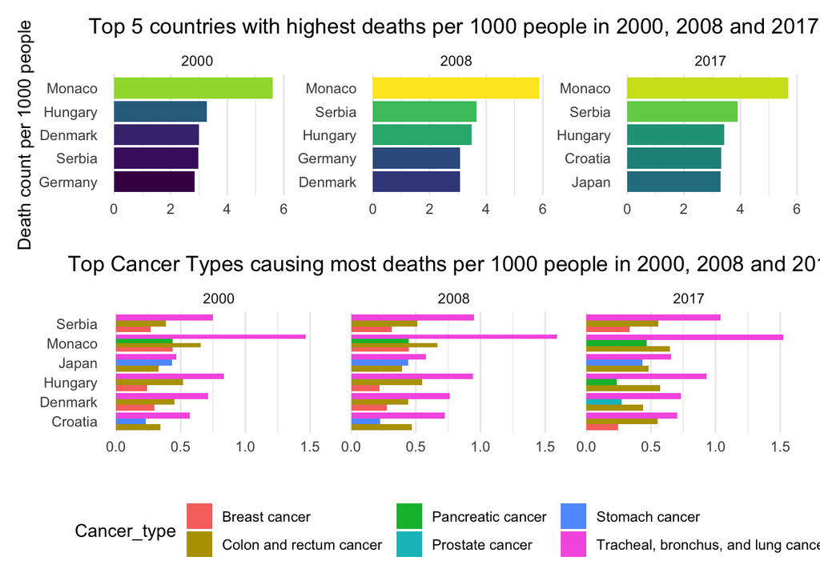

```r
fig2a/fig2b
```

=> High death rates by cancer highly concentrated around Europe. Here’s a link to maybe why? (EU vs USA)[https://www.politico.eu/article/cancer-europe-america-comparison/] - age? -> Maybe webscape data on Europe’s population age? (Cancer more likely as you get older) -

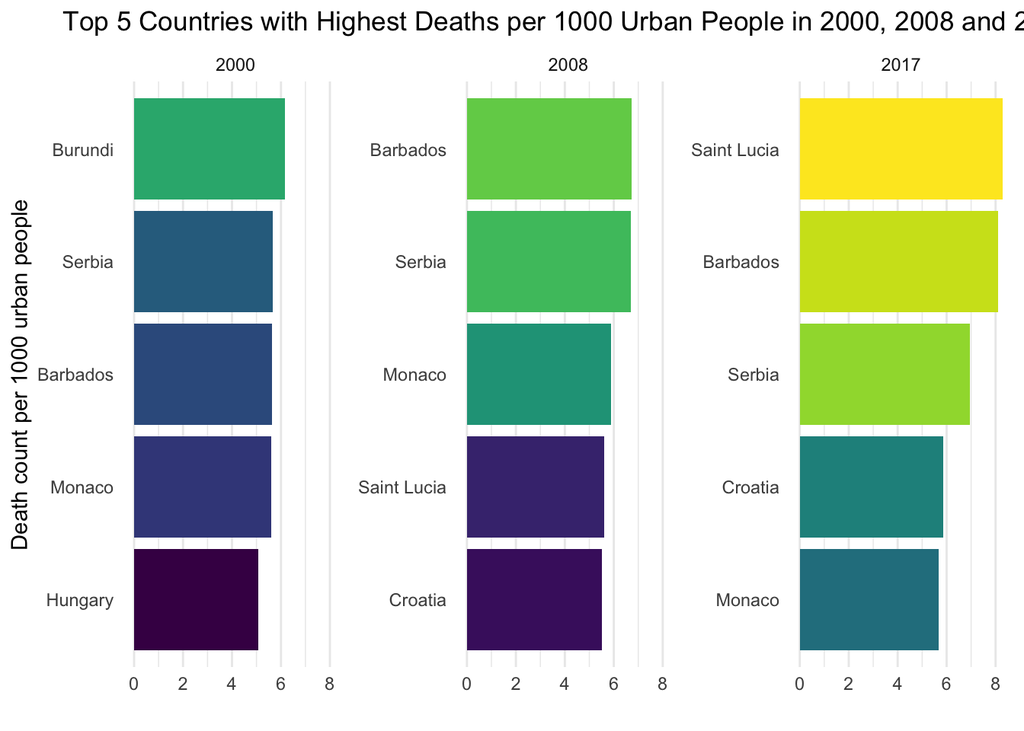

```r
fig3a <- top_5_cancer_pop %>%
  filter(year %in% c(2000,2008,2017)) %>%
  group_by(year) %>%
  slice_max(death_per_urban, n = 5) %>%
  ungroup() %>%
  mutate(country = reorder_within(country, death_per_urban, as.character(year), fun = sum, sep = "___")) %>%
  ggplot(aes(y = country, x = death_per_urban, fill = country)) +
  geom_col()+
  scale_fill_viridis_d()+
  facet_wrap(~year, scales = "free_y")+
  scale_y_reordered()+
  labs(title = "Top 5 Countries with Highest Deaths per 1000 Urban People in 2000, 2008 and 2017",
       x = "",
       y = "Death count per 1000 urban people")+
    theme(legend.position = "none",
          plot.title = element_text(hjust = 0.5),
          panel.grid.major.y = element_blank(),
          panel.grid.minor.y = element_blank())

fig3a
```

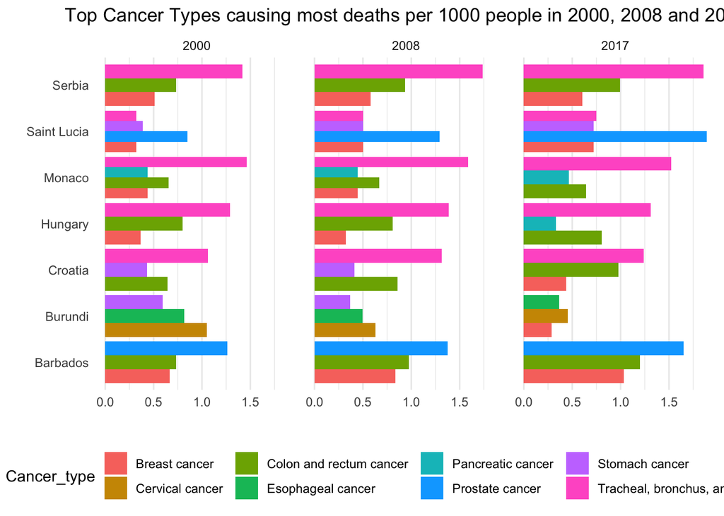

```r
fig3b <- cancer %>%
  rename(country_code = Code, year = Year) %>%
  filter(Entity %in% c("Burundi","Serbia","Barbados", "Monaco", "Hungary", "Croatia", "Saint Lucia"), year %in% c(2000,2008,2017)) %>%
  left_join(world_pop_new %>%
              filter(year %in% c(2000,2008,2017)) %>%
              mutate(year = as.numeric(year)),
            by = c("country_code","year")) %>%
  mutate(death_per_urban = Death_count/total_urban_population*1000, death_per_total = Death_count/ total_population*1000) %>%
  group_by(Entity, year) %>%
  slice_max(death_per_urban, n = 3) %>%
  ungroup() %>%
  ggplot(aes(y = Entity, x = death_per_urban, fill = Cancer_type ))+
  geom_col(position = "dodge")+
  facet_wrap(~year)+
  labs(title = "Top Cancer Types causing most deaths per 1000 people in 2000, 2008 and 2017",
       x = "",
       y = "",
       color = "Types of cancer")+
    theme(legend.position = "bottom",
          plot.title = element_text(hjust = 0.5),
          panel.grid.major.y = element_blank(),
          panel.grid.minor.y = element_blank())

fig3b
```

Observarion: besides the 3 cancer types mentioned earlier, we are also seeing prostate and pancreatic cancer.

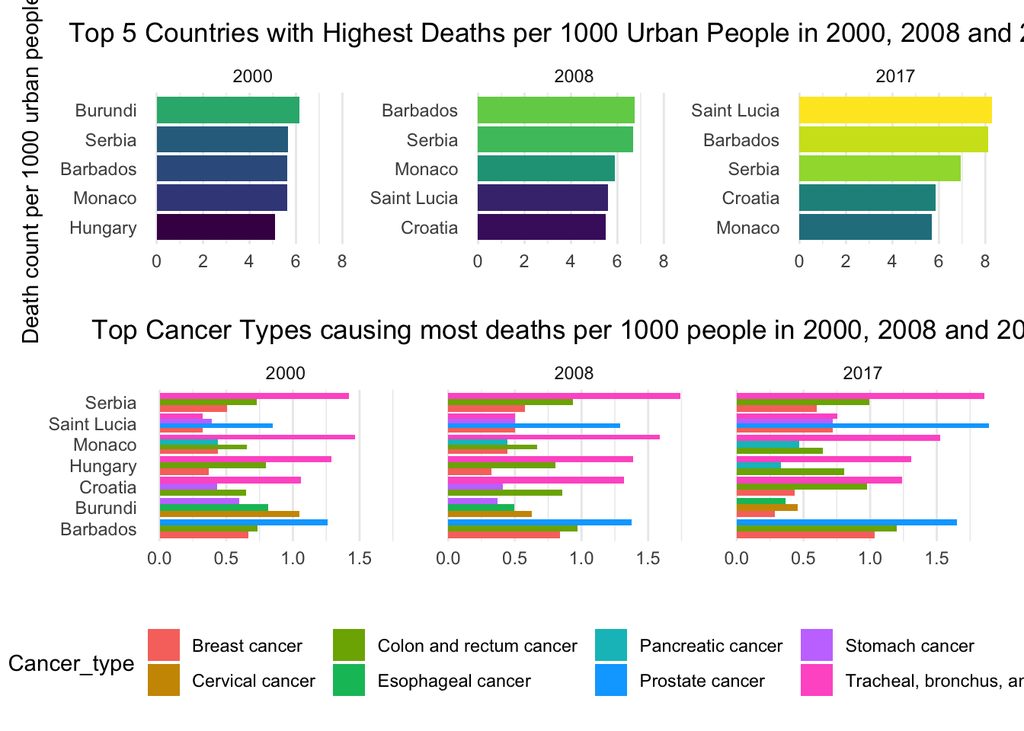

```r
fig3a / fig3b
```

```r
#comparing cancer death rates vs urban growth rate???
```

Discussion:

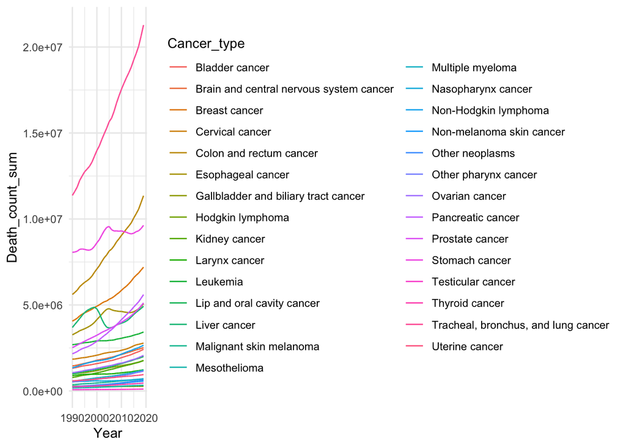

```r
cancer %>%
  group_by(Cancer_type, Year) %>%
  mutate(Death_count_sum = sum(Death_count)) %>%
  ggplot(aes(x = Year, y = Death_count_sum, color = Cancer_type)) +
    geom_line()
```

```r
#What is this doing? - Tam
```

**other potentially good stuff**

```r
#USA -<world_map %>%
#             filter(country == "USA") %>%
#             rename(country_code = country)
#  filter(country == "United States") %>%
#    ggplot() +
#  geom_map(map = ,
#           aes(map_id = country_code,
#               fill = death/total_population,
#               group = year)) +
#  expand_limits(x = world_map$long, y = world_map$lat)+
#  transition_time(date)+
#    labs(title = "",
#         subtitle = "Date : {frame_time}",
#       x="",
#       y ="")+
#  theme_map()+
#  theme(legend.background = element_blank(),
#        plot.title = element_text(hjust = 0.5))
#  animate(covid_time_map,
#          nframes = 300,
#          end_pause = 10)
```